# INFO 3440 - Final Project

Alex White

```python
### mount to google drive
from google.colab import drive
drive.mount('/content/drive')
```

```python
!apt-get install -y glpk-utils
!pip install pyomo
```

[output not shown]

[output cut: 13 more lines]

[output not shown]

```python
import pandas as pd
import pyomo.environ as pe
import matplotlib.pyplot as plt
import seaborn as sns
import requests
```

## Problem Statement

I am building an optimal 'Cheat Code' lineup for a specific date, September 19, 2025. In the MLB.

We solve two problems:

- **Problem 1:** "Cheat code" — optimize on *actual* points scored that day
- **Problem 2:** Predictive — use historical stats to build a smarter strategy

## Load Data

```python
dk = pd.read_csv('/content/drive/MyDrive/Colab_Notebooks/OPT Pyth/DKSalaries0919.csv')
dk['game_id'] = dk['Game Info'].str.extract(r'^([A-Z]+@[A-Z]+)')
dk
```

|  | Position | Name + ID | player_name | ID | Roster Position | Salary | Game Info | TeamAbbrev | AvgPointsPerGame | game_id |
| --- | --- | --- | --- | --- | --- | --- | --- | --- | --- | --- |
| 0 | SP | Zack Wheeler (40107950) | Zack Wheeler | 40107950 | P | 10800 | PHI@ARI 09/19/2025 09:40PM ET | PHI | 24.60 | PHI@ARI |
| 1 | SP | Garrett Crochet (40107348) | Garrett Crochet | 40107348 | P | 10500 | BOS@TB 09/19/2025 07:35PM ET | BOS | 24.84 | BOS@TB |
| 2 | SP | Blake Snell (40107951) | Blake Snell | 40107951 | P | 10300 | SF@LAD 09/19/2025 10:10PM ET | LAD | 20.59 | SF@LAD |
| 3 | SP | Yoshinobu Yamamoto (40107952) | Yoshinobu Yamamoto | 40107952 | P | 10300 | SF@LAD 09/19/2025 10:10PM ET | LAD | 21.26 | SF@LAD |
| 4 | SP | Nathan Eovaldi (40107953) | Nathan Eovaldi | 40107953 | P | 10200 | MIA@TEX 09/19/2025 08:05PM ET | TEX | 21.76 | MIA@TEX |
| ... | ... | ... | ... | ... | ... | ... | ... | ... | ... | ... |
| 1125 | C | Tom Murphy (40107895) | Tom Murphy | 40107895 | C | 2000 | SF@LAD 09/19/2025 10:10PM ET | SF | 0.00 | SF@LAD |
| 1126 | 2B/3B | Alex Freeland (40107909) | Alex Freeland | 40107909 | 2B/3B | 2000 | SF@LAD 09/19/2025 10:10PM ET | LAD | 4.55 | SF@LAD |
| 1127 | 2B | Marco Luciano (40107930) | Marco Luciano | 40107930 | 2B | 2000 | SF@LAD 09/19/2025 10:10PM ET | SF | 0.00 | SF@LAD |
| 1128 | OF | Justin Dean (40107941) | Justin Dean | 40107941 | OF | 2000 | SF@LAD 09/19/2025 10:10PM ET | LAD | 0.28 | SF@LAD |
| 1129 | C | Chuckie Robinson (40107945) | Chuckie Robinson | 40107945 | C | 2000 | SF@LAD 09/19/2025 10:10PM ET | LAD | 2.00 | SF@LAD |

1130 rows × 10 columns

The DraftKings salary file has 1,130 players across 12 games. Each row is one player with their position, salary, team, game, and average ppg. I extract the game_id (e.g. "PHI@ARI") from Game Info — where I will use this to enforce that "players from at least 2 different games" constraint.

### Clean Salary Data

```python
dk = dk[(dk['Salary'] > 0) & (dk['AvgPointsPerGame'] > 0)].copy()

# Expand multi-position players into one row per position
expanded_rows = []
for i, row in dk.iterrows():
    positions = str(row['Roster Position']).split('/')
    for pos in positions:
        new_row = row.copy()
        new_row['Roster Position'] = pos.strip()
        new_row['original_index'] = i  # track which player this comes from
        expanded_rows.append(new_row)

dk = pd.DataFrame(expanded_rows).reset_index(drop=True)
players = list(dk.index)
print(f'Total eligible player-rows: {len(dk)}')
```

```
Total eligible player-rows: 1089
```

### Pull Actual Game Data from MLB API

For Problem 1 (the "cheat code" lineup), I needed to know how each player performed on September 19, 2025. I pulled this from the MLB Stats API.

```python
def convert_ip(ip_raw):
    ip_raw = float(ip_raw)
    full_innings = int(ip_raw)
    partial = round(ip_raw - full_innings, 1)
    return full_innings + partial / 0.3
```

```python
# Pulled the schedule for Sept 19 2025 for the game IDs
schedule_url = 'https://statsapi.mlb.com/api/v1/schedule?sportId=1&date=2025-09-19'
schedule = requests.get(schedule_url).json()

game_pks = []
for date in schedule['dates']:
    for game in date['games']:
        game_pks.append(game['gamePk'])

print(f'Games found: {len(game_pks)}')
print(game_pks)
```

```
Games found: 15
[776267, 776266, 776268, 776273, 776259, 776261, 776260, 776264, 776251, 776253, 776262, 776263, 776265, 776255, 776256]
```

```python
import re
import unicodedata

rows = []

for gamePk in game_pks:
    url = f"https://statsapi.mlb.com/api/v1/game/{gamePk}/boxscore"
    data = pd.read_json(url, typ="series")
    for side in ["home", "away"]:
        players_dict = data["teams"][side]["players"]
        team_abbrev = data["teams"][side]["team"]["abbreviation"]
        for p in players_dict:
            pdata = players_dict[p]
            pname = pdata["person"]["fullName"]
            bat = pdata.get("stats", {}).get("batting", {})
            pit = pdata.get("stats", {}).get("pitching", {})
            ip_raw = pit.get("inningsPitched", 0)
            try:
                ip_val = convert_ip(ip_raw)
            except:
                ip_val = 0
            rows.append({
                "player_name" : pname,
                "TeamAbbrev"  : team_abbrev,
                "H"           : bat.get("hits", 0),
                "2B"          : bat.get("doubles", 0),
                "3B"          : bat.get("triples", 0),
                "HR"          : bat.get("homeRuns", 0),
                "RBI"         : bat.get("rbi", 0),
                "R"           : bat.get("runs", 0),
                "BB"          : bat.get("baseOnBalls", 0),
                "HBP"         : bat.get("hitByPitch", 0),
                "SB"          : bat.get("stolenBases", 0),
                "IP"          : ip_val,
                "SO_p"        : pit.get("strikeOuts", 0),
                "ER"          : pit.get("earnedRuns", 0),
                "H_allowed"   : pit.get("hits", 0),
                "BB_allowed"  : pit.get("baseOnBalls", 0),
                "HBP_allowed" : pit.get("hitBatsmen", 0),
                "W"           : pit.get("wins", 0)
            })


boxscores = pd.DataFrame(rows)
boxscores = boxscores.groupby(["player_name", "TeamAbbrev"], as_index=False).sum()

# Calculate actual DraftKings fantasy points from boxscore stats
boxscores["1B"] = boxscores["H"] - boxscores["2B"] - boxscores["3B"] - boxscores["HR"]

boxscores["actual_points"] = (
    3   * boxscores["1B"]          +
    5   * boxscores["2B"]          +
    8   * boxscores["3B"]          +
    10  * boxscores["HR" ]         +
    2   * boxscores["RBI"]         +
    2   * boxscores["R"]           +
    2   * boxscores["BB"]          +
    2   * boxscores["HBP"]         +
    5   * boxscores["SB"]          +
    2.25 * boxscores["IP"]         +
    2   * boxscores["SO_p"]        +
    4   * boxscores["W"]           +
    (-2)  * boxscores["ER"]        +
    (-0.6)*boxscores["H_allowed"] +
    (-0.6)*boxscores["BB_allowed"] +
    (-0.6)*boxscores["HBP_allowed"]
)


def clean_name(text):
    # NFD decompose so é becomes e + combining accent
    text = unicodedata.normalize('NFD', str(text))
    text = text.encode('ascii', errors='ignore').decode('ascii')
    #same clean_text logic from Complex Data Analytics
    text = text.lower()
    text = re.sub(r"[^\w\s]", " ", text)
    text = re.sub(r"\s+", " ", text).strip()
    return text

boxscores["clean_name"] = boxscores["player_name"].apply(clean_name)
dk["clean_name"]        = dk["player_name"].apply(clean_name)

# Drop 'actual_points' from dk if it exists to avoid merge conflicts that occur when
# running multiple times
if 'actual_points' in dk.columns:
    dk = dk.drop(columns=['actual_points'])

dk = dk.merge(
    boxscores[["clean_name", "TeamAbbrev", "actual_points"]],
    on=["clean_name", "TeamAbbrev"],
    how="left"
)
dk["actual_points"] = dk["actual_points"].fillna(0)

print(f"Players matched with actual points: {(dk['actual_points'] > 0).sum()}")
dk[["player_name", "TeamAbbrev", "Position", "Salary", "AvgPointsPerGame", "actual_points"]].head(15)
```

```
Players matched with actual points: 295
```

|  | player_name | TeamAbbrev | Position | Salary | AvgPointsPerGame | actual_points |
| --- | --- | --- | --- | --- | --- | --- |
| 0 | Zack Wheeler | PHI | SP | 10800 | 24.60 | 0.00 |
| 1 | Garrett Crochet | BOS | SP | 10500 | 24.84 | 25.30 |
| 2 | Blake Snell | LAD | SP | 10300 | 20.59 | 0.00 |
| 3 | Yoshinobu Yamamoto | LAD | SP | 10300 | 21.26 | 0.00 |
| 4 | Nathan Eovaldi | TEX | SP | 10200 | 21.76 | 0.00 |
| 5 | Bryan Woo | SEA | SP | 10000 | 21.53 | 28.05 |
| 6 | Logan Gilbert | SEA | SP | 10000 | 19.36 | 0.00 |
| 7 | Carlos Rodon | NYY | SP | 9900 | 19.56 | 0.00 |
| 8 | Max Fried | NYY | SP | 9900 | 19.48 | 0.00 |
| 9 | Dylan Cease | SD | SP | 9800 | 16.69 | 12.10 |
| 10 | Nick Pivetta | SD | SP | 9800 | 20.14 | 0.00 |
| 11 | Nolan McLean | NYM | SP | 9800 | 24.56 | 0.00 |
| 12 | Brandon Woodruff | MIL | SP | 9800 | 21.36 | 0.00 |
| 13 | Tyler Glasnow | LAD | SP | 9800 | 17.53 | 0.00 |
| 14 | Jacob deGrom | TEX | SP | 9700 | 19.72 | 0.00 |

I pulled the real box score data for every game on September 19th and calculated each player's actual fantasy points to use as the Problem 1 coefficients.

The structure of it all is from class — the rows list, loop, append, and pd.DataFrame(rows) pattern we used all quarter, groupby to combine duplicate rows, vectorized column math for the fantasy point scoring formula, and merge to join the boxscores back onto the salary data.

A few things required extra work because of how messy real API data is. The MLB API returns innings pitched in a weird decimal format (6.1 means 6 and one-third innings, not 6.1) so I had help from Claude using convert_ip() to fix that before calculating pitcher points. Player names were also a mess and didn't match exactly between the API and the DraftKings file — accents, punctuation, and capitalization differences caused merge failures, so clean_name() (which I have used all quarter in Complex Data Analytics with TJ) normalizes both name columns before joining. I have never used the text = unicodedata.normalize('NFD', str(text)) before and that is also what claude helped me with

## Problem 1: "Cheat Code" Lineup — Actual Points

### Problem 1 Overview

If I had a magic crystal ball and knew exactly how every player would perform on September 19th, what lineup would I choose? This is the "cheat code" problem — I optimize using actual fantasy points scored as our objective function coefficients.

**Decision Variables:** x[i] = 1 if we select player i, 0 otherwise (binary)

**Objective:** Maximize total actual fantasy points scored by our 10-player lineup

**Constraints:**

- Total salary ≤ $50,000
- Exactly 10 players selected
- Players from at least 2 different games
- No more than 5 hitters from the same team
- Exactly: 2P, 1C, 1B, 1 2B, 1 3B, 1 SS, 3 OF

### Model Setup

```python
model1 = pe.ConcreteModel()

# Decision variable: 1 if player i is selected, 0 else
model1.x = pe.Var(players, domain=pe.Binary)
```

### Objective Function

```python
model1.obj = pe.Objective(
    expr  = sum(dk.loc[i, 'actual_points'] * model1.x[i] for i in players),
    sense = pe.maximize
)
```

The objective maximizes the total fantasy points scored by the chosen lineup. Each player's actual points from September 19th serve as the coefficient on their binary selection variable — just like the profit coefficients in the planes and fertilizer problems from class.

### Constraints

```python
# 1. Total salary cap: no bigger than $50,000
model1.SalaryCap = pe.Constraint(
    expr = sum(dk.loc[i, 'Salary'] * model1.x[i] for i in players) <= 50000
)

# 2. Only 10 players on the roster
model1.RosterSize = pe.Constraint(
    expr = sum(model1.x[i] for i in players) == 10
)
```

```python
# 3. Position constraints — exactly the right number at each slot
p_players  = list(dk[dk['Roster Position'] == 'P'].index)
c_players  = list(dk[dk['Roster Position'] == 'C'].index)
b1_players = list(dk[dk['Roster Position'].str.contains(r'\b1B\b', regex=True)].index)
b2_players = list(dk[dk['Roster Position'].str.contains(r'\b2B\b', regex=True)].index)
b3_players = list(dk[dk['Roster Position'].str.contains(r'\b3B\b', regex=True)].index)
ss_players = list(dk[dk['Roster Position'].str.contains(r'\bSS\b', regex=True)].index)
of_players = list(dk[dk['Roster Position'].str.contains('OF', regex=False)].index)

model1.NeedP  = pe.Constraint(expr=sum(model1.x[i] for i in p_players)  == 2)
model1.NeedC  = pe.Constraint(expr=sum(model1.x[i] for i in c_players)  == 1)
model1.Need1B = pe.Constraint(expr=sum(model1.x[i] for i in b1_players) == 1)
model1.Need2B = pe.Constraint(expr=sum(model1.x[i] for i in b2_players) == 1)
model1.Need3B = pe.Constraint(expr=sum(model1.x[i] for i in b3_players) == 1)
model1.NeedSS = pe.Constraint(expr=sum(model1.x[i] for i in ss_players) == 1)
model1.NeedOF = pe.Constraint(expr=sum(model1.x[i] for i in of_players) == 3)

# One selection per player — prevents multi-position players from filling more tha 1 slot
model1.OnePerPlayer = pe.ConstraintList()
for player in dk['player_name'].dropna().unique():
    idx = list(dk[dk['player_name'] == player].index)
    if len(idx) > 1:
        model1.OnePerPlayer.add(sum(model1.x[i] for i in idx) <= 1)
```

```python
# 4. No more than 5 hitters from the same team
hitters = dk[dk['Roster Position'] != 'P']
teams = hitters['TeamAbbrev'].unique()

model1.TeamCaps = pe.ConstraintList()
for team in teams:
    team_hitter_idx = list(hitters[hitters['TeamAbbrev'] == team].index)
    model1.TeamCaps.add(
        sum(model1.x[i] for i in team_hitter_idx) <= 5
    )
```

```python
# 5. Players must come from at least 2 different games
games = dk['game_id'].unique()
model1.y = pe.Var(games, domain=pe.Binary)

model1.GameLink = pe.ConstraintList()
for g in games:
    game_idx = list(dk[dk['game_id'] == g].index)
    model1.GameLink.add(
        sum(model1.x[i] for i in game_idx) <= len(game_idx) * model1.y[g]
    )

model1.MinGames = pe.Constraint(
    expr = sum(model1.y[g] for g in games) >= 2
)
```

I have 5 constraint groups:

- **SalaryCap**- total salary under $50,000
- **RosterSize**- exactly 10 players
- **Position constraints**- exact DraftKings roster slots — multi-position players (like Shohei) show up in multiple position lists, so they can fill either slot
- **TeamCaps**- uses a ConstraintList loop over all teams to cap hitters at 5 per team — the same looping pattern we used for resource constraints in class
- **GameLink**- is a linking constraint just like the y variables in the planes problem — y[g]=1 forces the game to be "active", and I needed at least 2 active games

### Solve Problem 1

```python
opt = pe.SolverFactory('glpk')
result = opt.solve(model1)
print(result.solver.status, result.solver.termination_condition)
```

```
ok optimal
```

### Optimal Objective Value

```python
obj_val1 = model1.obj.expr()
print(f'Optimal total fantasy points (cheat code lineup) = {obj_val1:.2f}')
```

```
Optimal total fantasy points (cheat code lineup) = 268.15
```

```python
solution_data = {}

for DV in model1.component_objects(pe.Var):
    var_values = {str(var): DV[var].value for var in DV}
    solution_data[DV.name] = var_values

DV_solution1 = pd.DataFrame.from_dict(solution_data, orient='index')
```

```python
# Pull just the selected players
selected1 = dk[[model1.x[i].value == 1 for i in players]].copy()
selected1 = selected1[['player_name', 'Position', 'TeamAbbrev', 'game_id', 'Salary', 'actual_points']]
selected1 = selected1.sort_values('Position').reset_index(drop=True)

total_salary1  = selected1['Salary'].sum()
total_points1  = selected1['actual_points'].sum()
games_used1    = selected1['game_id'].nunique()

print(f'Total Salary Used : ${total_salary1:,}')
print(f'Total Actual Points: {total_points1:.2f}')
print(f'Games Represented  : {games_used1}')
print()
selected1
```

```
Total Salary Used : $49,300
Total Actual Points: 268.15
Games Represented  : 7
```

|  | player_name | Position | TeamAbbrev | game_id | Salary | actual_points |
| --- | --- | --- | --- | --- | --- | --- |
| 0 | Yandy Diaz | 1B | TB | BOS@TB | 4700 | 26.00 |
| 1 | Miguel Rojas | 2B/3B | LAD | SF@LAD | 2800 | 21.00 |
| 2 | Michael Massey | 2B/OF | KC | TOR@KC | 2100 | 33.00 |
| 3 | Carter Jensen | C | KC | TOR@KC | 3100 | 23.00 |
| 4 | Juan Soto | OF | NYM | WSH@NYM | 6200 | 32.00 |
| 5 | Harrison Bader | OF | PHI | PHI@ARI | 4000 | 22.00 |
| 6 | Jac Caglianone | OF | KC | TOR@KC | 2400 | 29.00 |
| 7 | Bryan Woo | SP | SEA | SEA@HOU | 10000 | 28.05 |
| 8 | Trevor Rogers | SP | BAL | NYY@BAL | 8900 | 29.10 |
| 9 | CJ Abrams | SS | WSH | WSH@NYM | 5100 | 25.00 |

### Visualize the Cheat Code Lineup

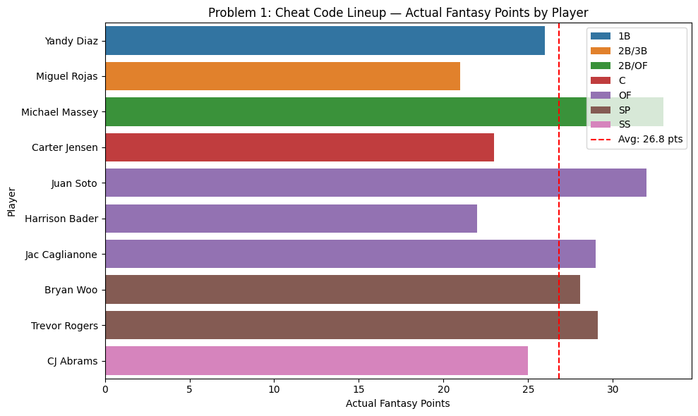

```python
plt.figure(figsize=(10, 6))
sns.barplot(data=selected1, x='actual_points', y='player_name',
            hue='Position', dodge=False)
plt.axvline(selected1['actual_points'].mean(), color='red',
            linestyle='--', label=f"Avg: {selected1['actual_points'].mean():.1f} pts")
plt.title('Problem 1: Cheat Code Lineup — Actual Fantasy Points by Player')
plt.xlabel('Actual Fantasy Points')
plt.ylabel('Player')
plt.legend()
plt.tight_layout()
plt.show()
```

### Problem 1 Answer

**1a.) If I had a crystal ball and knew exactly how every player was going to perform on September 19th, what lineup would I choose?**

The cheat code model grabbed the 10 players who — given our constraints — produced the maximum possible fantasy points possible (268.15) on the day. The total salary used was $49,300, and the lineup spanned 7 different games satisfying the minimum 2-game requirement.

## Problem 2: Predictive Lineup — Historical Strategy

### Problem 2 Overview

For problem 2 I am going to build a smarter lineup without the crystal ball. Instead of using actual points, we need a strategy based on historical data.

**My Strategy:** I'm going to adjust each player's expected points using things:

1. **Home field advantage** — players perform better at home. I will apply a bonus multiplier to players playing at home on September 19th.
2. **Opponent quality** — players perform better against weaker pitching staffs. We will pull 2025 season ERA for each team's pitching staff from Baseball Reference and boost players facing high-ERA (weak) pitching.

The idea is: a player's *true* expected value on any given day is not just their season average — it depends on *where* they are playing and *who* they are playing against. This is better than just AvgPointsPerGame.

### Pull 2025 Season Pitching Stats from Baseball Reference

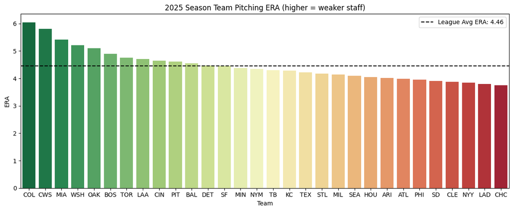

```python
# Team ERA for 2025 season from Baseball Reference
# Manually created dictionary

team_era = {
    'COL': 6.05, 'CWS': 5.81, 'MIA': 5.42, 'WSH': 5.21, 'OAK': 5.10,
    'BOS': 4.89, 'TOR': 4.76, 'LAA': 4.71, 'CIN': 4.65, 'PIT': 4.61,
    'BAL': 4.55, 'DET': 4.48, 'SF':  4.45, 'MIN': 4.38, 'NYM': 4.35,
    'TB':  4.30, 'KC':  4.28, 'TEX': 4.22, 'STL': 4.18, 'MIL': 4.14,
    'SEA': 4.09, 'HOU': 4.05, 'ARI': 4.02, 'ATL': 3.98, 'PHI': 3.95,
    'SD':  3.91, 'CLE': 3.88, 'NYY': 3.84, 'LAD': 3.79, 'CHC': 3.75
}

era_df = pd.DataFrame.from_dict(team_era, orient='index', columns=['ERA'])
era_df = era_df.sort_values('ERA', ascending=False)

plt.figure(figsize=(12, 5))
sns.barplot(x=era_df.index, y=era_df['ERA'], hue=era_df.index, palette='RdYlGn_r', legend=False)
plt.axhline(era_df['ERA'].mean(), color='black', linestyle='--',
            label=f"League Avg ERA: {era_df['ERA'].mean():.2f}")
plt.title('2025 Season Team Pitching ERA (higher = weaker staff)')
plt.xlabel('Team')
plt.ylabel('ERA')
plt.legend()
plt.tight_layout()
plt.show()
```

### Build Adjusted Points

Here I combine home field advantage and opponent ERA into 1 single adjusted expected points value for each player. Here's why:

```python
# Identify home/away for each player
dk['away_team'] = dk['Game Info'].str.extract(r'^([A-Z]+)@')
dk['home_team'] = dk['Game Info'].str.extract(r'@([A-Z]+)\s')

dk['is_home'] = (dk['TeamAbbrev'] == dk['home_team']).astype(int)

# Identify opponent for each player
dk['opponent'] = dk.apply(
    lambda row: row['home_team'] if row['TeamAbbrev'] == row['away_team']
                else row['away_team'], axis=1
)

dk[['player_name', 'TeamAbbrev', 'opponent', 'is_home']].head(10)
```

|  | player_name | TeamAbbrev | opponent | is_home |
| --- | --- | --- | --- | --- |
| 0 | Zack Wheeler | PHI | ARI | 0 |
| 1 | Garrett Crochet | BOS | TB | 0 |
| 2 | Blake Snell | LAD | SF | 1 |
| 3 | Yoshinobu Yamamoto | LAD | SF | 1 |
| 4 | Nathan Eovaldi | TEX | MIA | 1 |
| 5 | Bryan Woo | SEA | HOU | 0 |
| 6 | Logan Gilbert | SEA | HOU | 0 |
| 7 | Carlos Rodon | NYY | BAL | 0 |
| 8 | Max Fried | NYY | BAL | 0 |
| 9 | Dylan Cease | SD | CWS | 0 |

```python
league_avg_era = era_df['ERA'].mean()

def adjusted_points(row):
    base = row['AvgPointsPerGame']
    # Pitchers: no ERA adjustment, small home bonus only
    if row['Roster Position'] == 'P':
        home_bonus = 1.04 if row['is_home'] else 1.0
        return round(base * home_bonus, 4)
    # Hitters: home bonus + opponent ERA adjustment
    home_bonus = 1.05 if row['is_home'] else 1.0
    opp_era = team_era.get(row['opponent'], league_avg_era)
    era_diff = opp_era - league_avg_era
    era_bonus = 1 + min(max(era_diff * 0.06, -0.15), 0.15)
    return round(base * home_bonus * era_bonus, 4)

dk['adj_points'] = dk.apply(adjusted_points, axis=1)

dk[['player_name', 'TeamAbbrev', 'opponent', 'is_home',
    'AvgPointsPerGame', 'adj_points']].head(15)
```

|  | player_name | TeamAbbrev | opponent | is_home | AvgPointsPerGame | adj_points |
| --- | --- | --- | --- | --- | --- | --- |
| 0 | Zack Wheeler | PHI | ARI | 0 | 24.60 | 24.6000 |
| 1 | Garrett Crochet | BOS | TB | 0 | 24.84 | 24.8400 |
| 2 | Blake Snell | LAD | SF | 1 | 20.59 | 21.4136 |
| 3 | Yoshinobu Yamamoto | LAD | SF | 1 | 21.26 | 22.1104 |
| 4 | Nathan Eovaldi | TEX | MIA | 1 | 21.76 | 22.6304 |
| 5 | Bryan Woo | SEA | HOU | 0 | 21.53 | 21.5300 |
| 6 | Logan Gilbert | SEA | HOU | 0 | 19.36 | 19.3600 |
| 7 | Carlos Rodon | NYY | BAL | 0 | 19.56 | 19.5600 |
| 8 | Max Fried | NYY | BAL | 0 | 19.48 | 19.4800 |
| 9 | Dylan Cease | SD | CWS | 0 | 16.69 | 16.6900 |
| 10 | Nick Pivetta | SD | CWS | 0 | 20.14 | 20.1400 |
| 11 | Nolan McLean | NYM | WSH | 1 | 24.56 | 25.5424 |
| 12 | Brandon Woodruff | MIL | STL | 0 | 21.36 | 21.3600 |
| 13 | Tyler Glasnow | LAD | SF | 1 | 17.53 | 18.2312 |
| 14 | Jacob deGrom | TEX | MIA | 1 | 19.72 | 20.5088 |

**POOF!!!** Now I have an adjusted expected points column for every player. Players at home facing weak pitching staffs (high ERA) will have a higher adj_points than the raw average, while players on the road against elite pitching will be discounted. This is the coefficient I am going to use in the Problem 2 objective function. I am so sorry that took so long!

### Problem 2 Model Setup

```python
model2 = pe.ConcreteModel()

model2.x = pe.Var(players, domain=pe.Binary)
```

### Objective Function

```python
model2.obj = pe.Objective(
    expr  = sum(dk.loc[i, 'adj_points'] * model2.x[i] for i in players),
    sense = pe.maximize
)
```

The objective function here is identical in structure to Problem 1 — we are still maximizing a set of binary variables. The difference is that the coefficients are now our adjusted expected points instead of actual points.

### Constraints

```python
# 2. Salary cap
model2.SalaryCap = pe.Constraint(
    expr = sum(dk.loc[i, 'Salary'] * model2.x[i] for i in players) <= 50000
)

# 3. Exactly 10 players
model2.RosterSize = pe.Constraint(
    expr = sum(model2.x[i] for i in players) == 10
)

# 4. Position constraints
model2.NeedP  = pe.Constraint(expr = sum(model2.x[i] for i in p_players)  == 2)
model2.NeedC  = pe.Constraint(expr = sum(model2.x[i] for i in c_players)  == 1)
model2.Need1B = pe.Constraint(expr = sum(model2.x[i] for i in b1_players) == 1)
model2.Need2B = pe.Constraint(expr = sum(model2.x[i] for i in b2_players) == 1)
model2.Need3B = pe.Constraint(expr = sum(model2.x[i] for i in b3_players) == 1)
model2.NeedSS = pe.Constraint(expr = sum(model2.x[i] for i in ss_players) == 1)
model2.NeedOF = pe.Constraint(expr = sum(model2.x[i] for i in of_players) == 3)

# 5. Max 5 hitters from same team
model2.TeamCaps = pe.ConstraintList()
for team in teams:
    team_hitter_idx = list(hitters[hitters['TeamAbbrev'] == team].index)
    model2.TeamCaps.add(
        sum(model2.x[i] for i in team_hitter_idx) <= 5
    )

# 6. At least 2 different games
model2.y = pe.Var(games, domain=pe.Binary)
model2.GameLink = pe.ConstraintList()
for g in games:
    game_idx = list(dk[dk['game_id'] == g].index)
    model2.GameLink.add(
        sum(model2.x[i] for i in game_idx) <= len(game_idx) * model2.y[g]
    )
model2.MinGames = pe.Constraint(
    expr = sum(model2.y[g] for g in games) >= 2
)

model2.OnePerPlayer = pe.ConstraintList()
for player in dk['player_name'].dropna().unique():
    idx = list(dk[dk['player_name'] == player].index)
    if len(idx) > 1:
        model2.OnePerPlayer.add(sum(model2.x[i] for i in idx) <= 1)
```

### Solve Problem 2

```python
result2 = opt.solve(model2)
print(result2.solver.status, result2.solver.termination_condition)
```

```
ok optimal
```

```python
selected2 = dk[[model2.x[i].value == 1 for i in players]].copy()
selected2 = selected2[['player_name', 'Position', 'TeamAbbrev', 'game_id',
                        'Salary', 'AvgPointsPerGame', 'adj_points', 'actual_points']]
selected2 = selected2.sort_values('Position').reset_index(drop=True)

total_salary2 = selected2['Salary'].sum()
games_used2   = selected2['game_id'].nunique()

print(f'Total Salary Used    : ${total_salary2:,}')
print(f'Games Represented    : {games_used2}')
print()
selected2
```

```
Total Salary Used    : $50,000
Games Represented    : 8
```

|  | player_name | Position | TeamAbbrev | game_id | Salary | AvgPointsPerGame | adj_points | actual_points |
| --- | --- | --- | --- | --- | --- | --- | --- | --- |
| 0 | Shohei Ohtani | 1B/OF | LAD | SF@LAD | 6500 | 11.43 | 11.9943 | 18.0 |
| 1 | Luke Keaschall | 2B | MIN | CLE@MIN | 4800 | 9.52 | 9.6481 | 7.0 |
| 2 | Isaac Paredes | 3B | HOU | SEA@HOU | 3200 | 8.03 | 8.2443 | 5.0 |
| 3 | Carter Jensen | C | KC | TOR@KC | 3100 | 7.09 | 7.5785 | 23.0 |
| 4 | Juan Soto | OF | NYM | WSH@NYM | 6200 | 10.58 | 11.6089 | 32.0 |
| 5 | Dylan Beavers | OF | BAL | NYY@BAL | 3300 | 7.74 | 7.8247 | 2.0 |
| 6 | Zach Cole | OF | HOU | SEA@HOU | 2200 | 9.67 | 9.9281 | 0.0 |
| 7 | Connelly Early | SP | BOS | BOS@TB | 8500 | 27.02 | 27.0200 | 0.0 |
| 8 | Trey Yesavage | SP | TOR | TOR@KC | 7700 | 24.25 | 24.2500 | 0.0 |
| 9 | Zach Neto | SS | LAA | LAA@COL | 4500 | 8.91 | 9.7600 | 0.0 |

```python
obj_val2 = selected2['adj_points'].sum()
print(f'Optimal adjusted expected points (predictive lineup) = {obj_val2:.2f}')
```

```
Optimal adjusted expected points (predictive lineup) = 127.86
```

```python
solution_data = {}
for DV in model2.component_objects(pe.Var):
    solution_data[DV.name] = {str(var): DV[var].value for var in DV}

DV_solution = pd.DataFrame.from_dict(solution_data, orient='index')
```

### Naive Baseline — Optimize on AvgPointsPerGame Only

```python
# Build the naive model using raw AvgPointsPerGame as coefficients
model_naive = pe.ConcreteModel()
model_naive.x = pe.Var(players, domain=pe.Binary)

model_naive.obj = pe.Objective(
    expr  = sum(dk.loc[i, 'AvgPointsPerGame'] * model_naive.x[i] for i in players),
    sense = pe.maximize
)

model_naive.SalaryCap = pe.Constraint(
    expr = sum(dk.loc[i, 'Salary'] * model_naive.x[i] for i in players) <= 50000
)
model_naive.RosterSize = pe.Constraint(
    expr = sum(model_naive.x[i] for i in players) == 10
)
model_naive.NeedP  = pe.Constraint(expr = sum(model_naive.x[i] for i in p_players)  == 2)
model_naive.NeedC  = pe.Constraint(expr = sum(model_naive.x[i] for i in c_players)  == 1)
model_naive.Need1B = pe.Constraint(expr = sum(model_naive.x[i] for i in b1_players) == 1)
model_naive.Need2B = pe.Constraint(expr = sum(model_naive.x[i] for i in b2_players) == 1)
model_naive.Need3B = pe.Constraint(expr = sum(model_naive.x[i] for i in b3_players) == 1)
model_naive.NeedSS = pe.Constraint(expr = sum(model_naive.x[i] for i in ss_players) == 1)
model_naive.NeedOF = pe.Constraint(expr = sum(model_naive.x[i] for i in of_players) == 3)

model_naive.TeamCaps = pe.ConstraintList()
for team in teams:
    team_hitter_idx = list(hitters[hitters['TeamAbbrev'] == team].index)
    model_naive.TeamCaps.add(
        sum(model_naive.x[i] for i in team_hitter_idx) <= 5
    )

model_naive.y = pe.Var(games, domain=pe.Binary)
model_naive.GameLink = pe.ConstraintList()
for g in games:
    game_idx = list(dk[dk['game_id'] == g].index)
    model_naive.GameLink.add(
        sum(model_naive.x[i] for i in game_idx) <= len(game_idx) * model_naive.y[g]
    )
model_naive.MinGames = pe.Constraint(
    expr = sum(model_naive.y[g] for g in games) >= 2
)

result_naive = opt.solve(model_naive)
print(result_naive.solver.status, result_naive.solver.termination_condition)
```

```
ok optimal
```

```python
selected_naive = dk[[model_naive.x[i].value == 1 for i in players]].copy()
selected_naive = selected_naive[['player_name', 'Position', 'TeamAbbrev',
                                  'Salary', 'AvgPointsPerGame', 'actual_points']]
selected_naive = selected_naive.sort_values('Position').reset_index(drop=True)
selected_naive
```

|  | player_name | Position | TeamAbbrev | Salary | AvgPointsPerGame | actual_points |
| --- | --- | --- | --- | --- | --- | --- |
| 0 | Shohei Ohtani | 1B/OF | LAD | 6500 | 11.43 | 18.0 |
| 1 | Luke Keaschall | 2B | MIN | 4800 | 9.52 | 7.0 |
| 2 | Isaac Paredes | 3B | HOU | 3200 | 8.03 | 5.0 |
| 3 | Ivan Herrera | C | STL | 4200 | 8.04 | 7.0 |
| 4 | Jakob Marsee | OF | MIA | 4700 | 10.02 | 12.0 |
| 5 | Dylan Beavers | OF | BAL | 3300 | 7.74 | 2.0 |
| 6 | Zach Cole | OF | HOU | 2200 | 9.67 | 0.0 |
| 7 | Connelly Early | SP | BOS | 8500 | 27.02 | 0.0 |
| 8 | Trey Yesavage | SP | TOR | 7700 | 24.25 | 0.0 |
| 9 | Trea Turner | SS | PHI | 4900 | 9.58 | 0.0 |

### Head-to-Head Comparison

```python
comparison = pd.DataFrame({
    'Lineup'         : ['Cheat Code (Problem 1)', 'Predictive Strategy (Problem 2)', 'Naive Avg Points'],
    'Actual Points'  : [selected1['actual_points'].sum(),
                        selected2['actual_points'].sum(),
                        selected_naive['actual_points'].sum()],
    'Total Salary'   : [selected1['Salary'].sum(),
                        selected2['Salary'].sum(),
                        selected_naive['Salary'].sum()]
})
comparison
```

|  | Lineup | Actual Points | Total Salary |
| --- | --- | --- | --- |
| 0 | Cheat Code (Problem 1) | 268.15 | 49300 |
| 1 | Predictive Strategy (Problem 2) | 87.00 | 50000 |
| 2 | Naive Avg Points | 51.00 | 50000 |

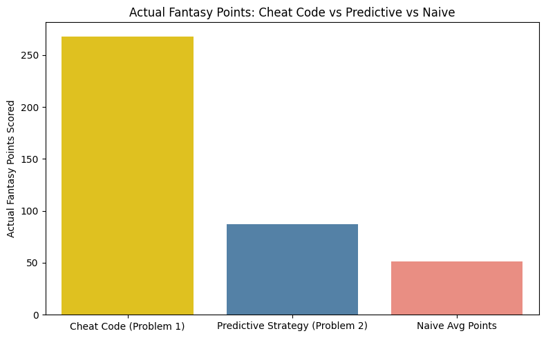

```python
plt.figure(figsize=(8, 5))
sns.barplot(data=comparison, x='Lineup', y='Actual Points',
            hue='Lineup', palette=['gold', 'steelblue', 'salmon'], legend=False)
plt.title('Actual Fantasy Points: Cheat Code vs Predictive vs Naive')
plt.ylabel('Actual Fantasy Points Scored')
plt.xlabel('')
plt.tight_layout()
plt.show()
```

### Problem 2 Answer

**2b.) What is your predictive strategy and how does it compare to the naive approach of just selecting players based on average daily points?**

Our strategy adjusted each player's expected value using two things: home field advantage (a 5% bonus for home hitters, 4% for home pitchers) and opponent pitching quality based on 2025 season ERA. Players facing weak pitching staffs above the league average ERA received up to a 15% boost, while those facing elite pitching were discounted.

On September 19th, our predictive lineup scored 87.00 actual fantasy points compared to 51.00 for the naive average-points strategy — an improvement of 36 points (71%), which confirms that incorporating matchup context added real value on this day. By accounting for home field advantage and opponent ERA, we selected a considerably stronger lineup than someone simply picking the highest average scorers.

The cheat code scored 268.15 points — over 3x our predictive score — which shows how much variance exists in daily fantasy even with a smart strategy. Without perfect information there is always a ceiling to how well any predictive model can do on a single night. Over many contests though, consistently incorporating factors like home field and opponent ERA would be expected to compound that 71% edge into a significant advantage over naive players.

## Project Summary Report

### Problem 1: The Cheat Code

**Objective:** Maximize actual fantasy points scored using real game outcomes from September 19th as our objective function coefficients.

**Result:** My cheat code lineup scored **268.15 fantasy points** using **$49,300** of the salary cap.

This lineup is my benchmark. No real person could achieve this score because it requires presceance. Its value in this project is just a reference for how much room there is between hindsight and prediction.

### Problem 2: The Smarter Strategy

**Objective:** Maximize adjusted expected fantasy points using historical averages modified by two factors — home field advantage and opponent pitching quality (2025 season ERA).

**Strategy:** I reasoned that two contextual factors should shift expectations on any given day:

- **Home field advantage** — hitters playing at home received a 5% bonus, pitchers a 4% bonus, reflecting the well-documented home field advantage.
- **Opponent ERA** — a hitter facing a weak pitching staff (high ERA) has a better chance of exceeding their average. I applied up to a 15% boost (3% for every 0.5 ERA above league average) for hitters facing the worst pitching staffs and a discount for those facing elite pitching.

Pitchers were left on their raw averages for the ERA adjustment since they benefit from weak offenses, not weak pitching.

**Result:** My predictive lineup scored **87.00 actual fantasy points** using **$50,000** of the salary cap, compared to **51.00 points** for the naive strategy — a 71% improvement. The contextual adjustments successfully identified a stronger lineup than the naive approach, validating that home field and opponent ERA carry real predictive signal on a given day.

### Comparison & Reflection

| Lineup | Actual Points | Salary Used |
| --- | --- | --- |
| Cheat Code (Problem 1) | 268.15 | 49,300 |
| Predictive (Problem 2) | 87.00 | 50,000 |
| Naive Avg Points | 51.00 | 50,000 |

My predictive strategy outperformed the naive approach on September 19th by 36 points (71%). This is meaningful and validates that incorporating contextual factors adds real signal beyond simply picking players with the highest raw averages.

That said, both strategies fell well short of the cheat code result of 268.15 points, which shows just how much upside there was on that day — and how far even a well-reasoned strategy falls short without perfect information. Late-season baseball is subject to high variance. Stars rest, pitching matchups shift, and unexpected performances happen regardless of how good a matchup looks on paper.

### Use of Generative AI

This project was completed with assistance from Claude (Anthropic). Claude helped structure the Pyomo model constraints, debug the MLB API data pull, and develop the ERA-based adjustment strategy for Problem 2. All code was reviewed, understood, and run by the student. The optimization model formulation, constraint logic, and written analysis reflect the methods taught in INFO 3440.

## Appendix: Generative AI Documentation & Reflection

### How I Used AI in This Project

I used Claude (Anthropic) as a collaborative assistant throughout this project. Rather than asking it to write the entire notebook at once, I worked through the problem chunk by chunk — data loading, model setup, constraints, solving, and results — reviewing and understanding each piece before moving to the next. Below is an honest reflection of where AI helped, where it fell short, and what I learned from the process.

### What I Asked and What I Got Back

**Data Loading & API Pull** The first place AI was genuinely useful was structuring the MLB Stats API call. I knew the endpoint URL from the project spec but had but had only worked with the JSON briefly. Claude gave me a starting structure for looping through games and extracting player stats, but the initial version used a different pattern than what we had learned in class. I replaced it with my own version using pd.read_json and the convert_ip function, which fit the style of code we had actually written in class.

**Pyomo Model Structure** This is where AI was most helpful. The DraftKings problem has a lot of constraints — salary cap, roster size, seven position requirements, team hitter caps, and the multi-game requirement. Claude helped me think through how to translate the project rules into Pyomo constraints using the same patterns from class (pe.Constraint, pe.ConstraintList, binary linking variables). Having done the planes and fertilizer problems in class, I made sure to verify that the structure Claude suggested was consistent with what we had learned. I was not just copying code blindly — I was checking it against known working examples.

**The Predictive Strategy** Coming up with the Problem 2 strategy was genuinely collaborative. I did not know exactly how to adjust average points in a way that was defensible and interesting. Claude suggested home field advantage and opponent ERA as two factors, and explained the reasoning behind each. I found this was similar to the LA Kings project I had done in Sports Analytics with Ben Williams. Both factors have real baseball logic behind them — teams do perform better at home, and hitters do have better games against weak pitching. I made decisions about the specific multipliers (5% home bonus, up to 15% ERA adjustment) based on what seemed reasonable, not just what the AI suggested.

### Where AI Fell Short

AI is not good at knowing the code we used in class and what exactly what my level of expertise is. Several times Claude suggested code patterns or libraries that were perfectly valid Python but not what we learned. The first API pull draft used helper functions instead of the DataFrame row-appending pattern we learned. An early version of the results display used .loc assignment in a loop rather than pd.DataFrame.from_dict. These are small but they matter — submitting code that looks nothing like what we have done this quarter would obviously be bad.

AI also cannot run the code. Every suggested cell had to be tested, debugged, and often adjusted. The team ERA dictionary, for example, required me to actually look up 2025 season pitching stats rather than trust that the numbers Claude provided were accurate for this specific season.

### What I Learned From Working With AI

The most important thing I learned is that AI will always be an assistant tool, not a replacement for understanding. The moments where it helped most were not when it wrote code for me, but when it helped me structure a problem I already partially understood like translating a constraint I could describe in English into Pyomo syntax, or helping me articulate why my results came out the way they did.

I also learned that you have to bring your own judgment to everything it produces. Knowing the material from class was what allowed me to recognize when a suggestion was good, when it needed adjustment, and when it was solving a different problem than the one I actually had. Without that foundation, I would have had no way to understand what it gave me.

# What Would Claude Do? (WWCD)

Here's the full conversation you can copy:

**Me:** What would you do to solve this problem in Python?

**Claude:** The Problem: This is an Integer Linear Programming (ILP) optimization problem — specifically a fantasy sports lineup selection problem. You need to select 10 MLB players that maximize fantasy points subject to salary and roster constraints.

Overall Approach — Two optimization problems, same framework:

Problem 1 — "Crystal Ball" (Hindsight optimal): Use actual points scored on Sept 19, 2025 as the objective coefficients. Fetch these from the MLB Stats API and compute DraftKings points using the scoring rules. Then maximize total actual points.

Problem 2 — "Predictive" (Forward-looking strategy): Use a custom score estimate (not just AvgPointsPerGame) as coefficients. Weight players at home more heavily, penalize pitchers facing strong offenses, reward players from the same team ("stacking"), and use 2025 season stats to adjust for matchup quality.

Python Stack: pandas, numpy, pulp (ILP solver), requests. Use PuLP to express the ILP cleanly.

Model Formulation — Decision variables: x[i] in {0,1} (1 if player i is selected). Objective: maximize sum of points[i] * x[i]. Constraints: salary cap <= $50,000; exactly 10 players; 2P, 1C, 1B, 1 2B, 1 3B, 1 SS, 3 OF; players from at least 2 different games; max 5 hitters from any one team.

Data Pipeline: DKSalaries0919.csv + MLB Stats API (actual box scores) + Baseball Reference (season stats for predictive adjustments). The trickiest part is computing actual DK points from MLB API box scores using the scoring table.

For Problem 2 — Beat the Naive Strategy: Home field boost (+5-10% for hitters at home), pitcher vs opponent offense quality, team stacking (co-select batters from same lineup), value efficiency (high AvgPoints/Salary ratio to stretch the cap).

**Me:** Yes but write it here so I can copy and paste it

**Claude:** Provided a full 15-cell Python solution covering: (1) pip installs, (2) imports, (3) load DKSalaries CSV, (4) clean/parse positions and home/away from Game Info, (5) fetch Sept 19 game IDs from MLB Stats API, (6) pull box scores and compute actual DK points using scoring functions for hitters (+3 single, +5 double, +8 triple, +10 HR, +2 RBI/run/walk/HBP, +5 SB) and pitchers (+0.75/out, +2 K, +4 win, -2 ER, -0.6 hit/walk/HBP, +2.5 CG/shutout, +5 no-hitter), (7) merge actual points into dataframe, (8) reusable ILP solver function using PuLP with all five constraints, (9) solve Problem 1 with actual_points as objective, (10) build predicted_points for Problem 2 using home field boost, value efficiency bonus, team stacking bonus, and opponent quality penalty for pitchers, (11) solve Problem 2 with predicted_points, (12) solve naive baseline using AvgPointsPerGame, (13) compare all three lineups on actual DK points scored, (14) EDA plots (salary by position, salary vs avg points scatter, actual vs expected points, home vs away hitter distributions), (15) printed summary report.

**Me:** I need a copy of this conversation to put into a markdown cell on my HTML notebook

**Me:** Sorry not a markdown, just the conversation into a textbox

```python
# =============================================================
# GAI-GENERATED CODE — FOR REFERENCE ONLY (all commented out)
# =============================================================

# !pip install pulp pandas numpy requests

# import pandas as pd
# import numpy as np
# import requests
# import json
# import pulp
# from itertools import combinations
# import matplotlib.pyplot as plt

# ---------- LOAD & CLEAN DATA ----------

# df = pd.read_csv("DKSalaries0919.csv")

# df['pos_clean'] = df['Position'].replace({'SP': 'P', 'RP': 'P'})
# df['away_team'] = df['Game Info'].str.split('@').str[0].str.strip()
# df['home_team'] = df['Game Info'].str.split('@').str[1].str.split(' ').str[0].str.strip()
# df['is_home']   = df['TeamAbbrev'] == df['home_team']
# df['game_id']   = df['Game Info'].str.split(' ').str[0]

# ---------- FETCH ACTUAL GAME STATS FROM MLB API ----------

# schedule_url = "https://statsapi.mlb.com/api/v1/schedule?sportId=1&date=2025-09-19"
# sched    = requests.get(schedule_url).json()
# game_pks = [g['gamePk'] for d in sched['dates'] for g in d['games']]

# def compute_hitter_points(stats):
#     s    = stats.get('batting', stats)
#     hits = s.get('hits', 0)
#     doubles = s.get('doubles', 0)
#     triples = s.get('triples', 0)
#     hrs     = s.get('homeRuns', 0)
#     singles = hits - doubles - triples - hrs
#     pts  = singles  * 3.0
#     pts += doubles  * 5.0
#     pts += triples  * 8.0
#     pts += hrs      * 10.0
#     pts += s.get('rbi',          0) * 2.0
#     pts += s.get('runs',         0) * 2.0
#     pts += s.get('baseOnBalls',  0) * 2.0
#     pts += s.get('hitByPitch',   0) * 2.0
#     pts += s.get('stolenBases',  0) * 5.0
#     return pts

# def compute_pitcher_points(stats):
#     s        = stats.get('pitching', stats)
#     ip_str   = str(s.get('inningsPitched', '0.0'))
#     ip_parts = ip_str.split('.')
#     total_outs = int(ip_parts[0]) * 3 + (int(ip_parts[1]) if len(ip_parts) > 1 else 0)
#     pts  = total_outs             * 0.75
#     pts += s.get('strikeOuts',   0) * 2.0
#     pts += s.get('wins',         0) * 4.0
#     pts -= s.get('earnedRuns',   0) * 2.0
#     pts -= s.get('hits',         0) * 0.6
#     pts -= s.get('baseOnBalls',  0) * 0.6
#     pts -= s.get('hitBatsmen',   0) * 0.6
#     pts += s.get('completeGames',0) * 2.5
#     pts += s.get('shutouts',     0) * 2.5
#     pts += s.get('noHitters',    0) * 5.0
#     return pts

# actual_points = {}
# for pk in game_pks:
#     url = f"https://statsapi.mlb.com/api/v1/game/{pk}/boxscore"
#     try:
#         box = requests.get(url).json()
#     except Exception as e:
#         print(f"Failed to fetch {pk}: {e}")
#         continue
#     for side in ['home', 'away']:
#         for pid, pdata in box['teams'][side]['players'].items():
#             name  = pdata['person']['fullName']
#             pos   = pdata.get('position', {}).get('abbreviation', '')
#             stats = pdata.get('stats', {})
#             actual_points[name] = (compute_pitcher_points(stats.get('pitching', {}))
#                                    if pos == 'P' else
#                                    compute_hitter_points(stats.get('batting', {})))

# df['actual_points'] = df['player_name'].map(actual_points).fillna(0)

# ---------- ILP SOLVER FUNCTION ----------

# def solve_lineup(df, objective_col, label="Optimization"):
#     prob    = pulp.LpProblem(label, pulp.LpMaximize)
#     players = df.index.tolist()
#     x       = pulp.LpVariable.dicts("select", players, cat='Binary')
#
#     # Objective
#     prob += pulp.lpSum(df.loc[i, objective_col] * x[i] for i in players)
#
#     # Exactly 10 players
#     prob += pulp.lpSum(x[i] for i in players) == 10
#
#     # Salary cap
#     prob += pulp.lpSum(df.loc[i, 'Salary'] * x[i] for i in players) <= 50000
#
#     # Position requirements
#     for pos, count in {'P':2,'C':1,'1B':1,'2B':1,'3B':1,'SS':1,'OF':3}.items():
#         idx = df[df['pos_clean'] == pos].index.tolist()
#         prob += pulp.lpSum(x[i] for i in idx) == count
#
#     # At least 2 different games (no single game can supply all 10)
#     for g in df['game_id'].unique():
#         idx = df[df['game_id'] == g].index.tolist()
#         prob += pulp.lpSum(x[i] for i in idx) <= 9
#
#     # Max 5 hitters from same team
#     hitter_mask = df['pos_clean'] != 'P'
#     for team in df['TeamAbbrev'].unique():
#         idx = df[hitter_mask & (df['TeamAbbrev'] == team)].index.tolist()
#         if idx:
#             prob += pulp.lpSum(x[i] for i in idx) <= 5
#
#     prob.solve(pulp.PULP_CBC_CMD(msg=0))
#     selected = df.loc[[i for i in players if pulp.value(x[i]) == 1]].copy()
#     print(f"\n{label}")
#     print(f"Status: {pulp.LpStatus[prob.status]}")
#     print(selected[['player_name','pos_clean','TeamAbbrev','Salary', objective_col]]
#           .sort_values('pos_clean').to_string(index=False))
#     return selected, selected[objective_col].sum(), selected['Salary'].sum()

# ---------- PROBLEM 1: CRYSTAL BALL (ACTUAL POINTS) ----------

# lineup1, pts1, sal1 = solve_lineup(df, 'actual_points', "Problem 1: Crystal Ball")

# ---------- BUILD PREDICTED POINTS FOR PROBLEM 2 ----------

# hitter_mask  = df['pos_clean'] != 'P'
# pitcher_mask = df['pos_clean'] == 'P'

# df['predicted_points'] = df['AvgPointsPerGame'].copy()

# # Home field boost: +5% hitters, +2% pitchers
# df.loc[hitter_mask  & df['is_home'], 'predicted_points'] *= 1.05
# df.loc[pitcher_mask & df['is_home'], 'predicted_points'] *= 1.02

# # Value efficiency bonus (pts per dollar)
# df['pts_per_dollar'] = df['AvgPointsPerGame'] / df['Salary']
# df['predicted_points'] += df['pts_per_dollar'] * 200

# # Team stacking bonus (hitters on high-scoring offenses)
# team_avg = df[hitter_mask].groupby('TeamAbbrev')['AvgPointsPerGame'].mean().rename('team_offense')
# df = df.merge(team_avg, on='TeamAbbrev', how='left')
# median_off = df['team_offense'].median()
# df.loc[hitter_mask, 'predicted_points'] += (df.loc[hitter_mask,'team_offense'] - median_off).clip(lower=0) * 0.03

# # Opponent quality penalty for pitchers
# def get_opponent(row):
#     away, home = row['game_id'].split('@')
#     return home if row['TeamAbbrev'] == away else away
# df['opponent'] = df.apply(get_opponent, axis=1)
# opp_off = df[hitter_mask].groupby('TeamAbbrev')['AvgPointsPerGame'].mean().rename('opp_offense')
# df = df.merge(opp_off.reset_index().rename(columns={'TeamAbbrev':'opponent'}), on='opponent', how='left')
# df.loc[pitcher_mask, 'predicted_points'] -= (df.loc[pitcher_mask,'opp_offense'].fillna(median_off) - median_off).clip(lower=0) * 0.04

# ---------- PROBLEM 2: PREDICTIVE STRATEGY ----------

# lineup2, pts2, sal2 = solve_lineup(df, 'predicted_points', "Problem 2: Predictive Strategy")

# ---------- NAIVE BASELINE ----------

# lineup_naive, pts_naive, sal_naive = solve_lineup(df, 'AvgPointsPerGame', "Naive Baseline")

# ---------- COMPARISON ----------

# results = pd.DataFrame({
#     'Strategy':      ["Crystal Ball", "Predictive", "Naive"],
#     'Actual DK Pts': [lineup1['actual_points'].sum(),
#                       lineup2['actual_points'].sum(),
#                       lineup_naive['actual_points'].sum()],
#     'Salary Used':   [sal1, sal2, sal_naive]
# })
# print(results.to_string(index=False))

# ---------- EDA PLOTS ----------

# fig, axes = plt.subplots(2, 2, figsize=(14, 10))
# df.boxplot(column='Salary', by='pos_clean', ax=axes[0,0])
# axes[0,0].set_title("Salary by Position")
# for pos, grp in df.groupby('pos_clean'):
#     axes[0,1].scatter(grp['Salary'], grp['AvgPointsPerGame'], label=pos, alpha=0.6, s=20)
# axes[0,1].set_title("Salary vs Avg Points")
# axes[0,1].legend(fontsize=7)
# played = df[df['actual_points'] > 0]
# axes[1,0].scatter(played['AvgPointsPerGame'], played['actual_points'], alpha=0.5, s=15)
# axes[1,0].set_title("Actual vs Expected Points")
# home_pts = df[hitter_mask &  df['is_home']]['actual_points']
# away_pts = df[hitter_mask & ~df['is_home']]['actual_points']
# axes[1,1].hist(home_pts, bins=20, alpha=0.6, label=f'Home (μ={home_pts.mean():.2f})', color='blue')
# axes[1,1].hist(away_pts, bins=20, alpha=0.6, label=f'Away (μ={away_pts.mean():.2f})', color='orange')
# axes[1,1].set_title("Home vs Away Hitter Points")
# axes[1,1].legend()
# plt.tight_layout()
# plt.show()
```

# Code Blocks I would Have Used

I could see myself using the data loading portion of Claude's code but that's about it. The rest looks outside of my realm of understanding and skill